# Simulation

emphasis notes

## Non-Homogeneous Poisson Process

In a Non-Homogeneous Poisson Process (NHPP), the rate of events, denoted as $\lambda(t)$, is a function of time, allowing for varying event intensities at different times. This characteristic makes NHPP particularly useful in phylogenetic analysis for modeling non-constant events like speciation or extinction.

The probability distribution of an exponential waiting time in an NHPP, with a rate function $\lambda(t)$, is given by:
$$f(T=t) = \lambda(t) e^{-\int_0^t \lambda(u) du}$$

This formula reflects the likelihood of an event occurring at time $t$ given the cumulative rate up to that time.

To sample random variables (event times) from NHPP, one can use the `nhExpRand` function in R. This function generates event times considering the varying rate of occurrences over time. Here’s how to practically implement this function with a custom rate function:

```r
# Define a rate function for the NHPP
rate_function_example <- function(t) { 0.5 + 0.7*sin(t) }

# Set parameters for sampling
n_samples = 5000   # Number of event times to sample
now = 0          # Start time
tMax = 20        # Maximum time limit

# Sample event times from the NHPP
nhpp_event_times <- nhExpRand(n_samples, rate_function_example, now, tMax)

# Print the sampled event times
#print(nhpp_event_times)

# Density histogram of sampled event times
hist(nhpp_event_times, breaks = 100, col = 'skyblue', freq = FALSE,
     main = 'Density Histogram of NHPP Sampled Event Times',
     xlab = 'Event Time', ylab = 'Density')


# Adding a line plot for the rate function
curve(rate_function_example, from = now, to = tMax, add = TRUE, col = 'red', lwd = 2)
```

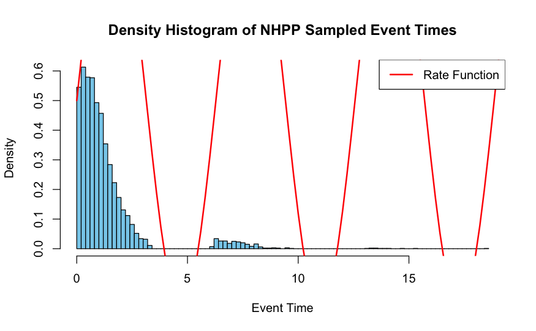

```r
legend('topright', legend = 'Rate Function', col = 'red', lwd = 2)
```

In species evolutionary processes, understanding the rate of change at a specific time is crucial for modeling dynamics such as speciation or extinction. This rate can be influenced by various environmental and ecological factors, which themselves change over time. By modeling the rate, denoted as $\lambda(t)$, as a function of time-dependent covariates, we create a more realistic and dynamic representation of these processes.

### Rate Calculation

Given these covariates, the rate $\lambda(t)$ at a specific time `t` is calculated using a combination of parameters that weigh the influence of each covariate:

1. **Covariate Values Calculation:** For each covariate function $f_i(t)$ in `cov_funcs`, calculate its value at time `t`, denoted as $c_i(t)$.
2. **Linear Combination of Parameters and Covariates:** The linear combination, denoted as $\eta(t)$, is initially computed as a linear combination of parameters and the covariate values. If `params` is a vector of parameters $[ \beta_0, \beta_1, \beta_2, \ldots, \beta_n ]$, where $\beta_0$ is the baseline rate, the linear combination is:
   $$\eta(t) = \beta_0 + \sum_{i=1}^{n} \beta_i \cdot c_i(t)$$
3. **Transformation Function (Optional):** If `use_exponential` is TRUE, the rate $\lambda(t)$ is transformed using a general function $g(\cdot)$, which could be an exponential transformation or another suitable function:
   $$\lambda(t) = g(\eta(t))$$
   Otherwise, $\eta(t)$ itself is used as the rate.

This mathematical formulation allows for a versatile and dynamic representation of rates in species evolutionary processes, capturing the nuances and complexities of biological systems over time.

#### Example 1. Sinuosoidal covariates

```r
# Define example covariate functions
cov_func1 <- function(t) { sin(t) }
cov_func2 <- function(t) { cos(t) }

# Example parameters (baseline and coefficients for covariates)
params <- c(0.5, 1.2, -0.8)


# Generate a sequence of time points
time_points <- seq(0, 10, by = 0.1)

# Compute covariate values and rate at each time point
cov_values1 <- sapply(time_points, cov_func1)
cov_values2 <- sapply(time_points, cov_func2)
rate_values <- sapply(time_points, function(t) rate_t(t, params,
                              list(cov_func1, cov_func2), use_exponential = TRUE))


# Plotting the covariate functions and rate function
plot(time_points, cov_values1, type = 'l', col = 'blue', ylim = range(c(cov_values1, cov_values2, rate_values)),
     main = 'Covariates and Rate Function', xlab = 'Time', ylab = 'Values / Rate', lty = 2)
lines(time_points, cov_values2, col = 'green', lty = 2)
```

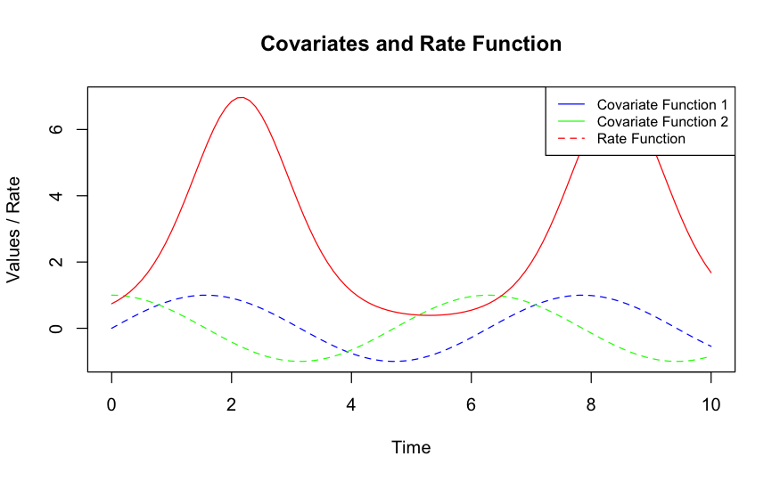

```r
lines(time_points, rate_values, col = 'red') # Using a different line type for rate

# Adding a legend
legend('topright', legend = c('Covariate Function 1', 'Covariate Function 2', 'Rate Function'),
       col = c('blue', 'green', 'red'), lty = c(1, 1, 2), cex = 0.8)
```

```r
NA
NA
```

### Simulation of Phylogenetic Trees

In the study of evolutionary biology, phylogenetic trees represent the relationships between species or other taxonomic units based on genetic, morphological, or other types of data. Simulating phylogenetic trees allows researchers to understand and predict evolutionary patterns and processes. It provides a framework for testing biological hypotheses about the mechanisms of evolution, speciation, and extinction.

#### Phylogenetic Diversification (PD) Model

```r
# Install and load the required packages
if (!requireNamespace("ape", quietly = TRUE)) {
  install.packages("ape")
}
library(ape)

# Example parameter set
pars <- params <- c(mu = 0.1, lambda_0 = 0.5, beta_N = -0.02, beta_P = 0.03)
max_t <- 10
max_lin <- 1e6
max_tries <- 100

tree = emphasis:::sim_tree_pd_cpp(pars, max_t, max_lin, max_tries)$tes

time_points = seq(0,max_t,length.out = 100)
# Compute species richness (number of lineages) over time
richness_values <- sapply(time_points, function(t) sum(ape:::branching.times(tree) < t))

# Compute phylogenetic diversity over time
diversity_values <- sapply(time_points, function(t) sum(ape:::branching.times(tree)[ape:::branching.times(tree) < t]))

# Compute speciation rate
speciation_rate_values <- sapply(time_points, function(t) {
  Nt <- richness_values[t]
  Pt <- diversity_values[t]
  lambda_t <- max(0, params['lambda_0'] + params['beta_N'] * Nt + params['beta_P'] * Pt / max(Nt, 1))
  return(lambda_t)
})

# Plotting the results
plot(time_points, richness_values, type = 'l', col = 'blue', lty = 2,
     ylim = range(c(richness_values, diversity_values, speciation_rate_values)),
     main = 'PD Model Visualization', xlab = 'Time', ylab = 'Values / Rate')
lines(time_points, diversity_values, col = 'green', lty = 2)
```

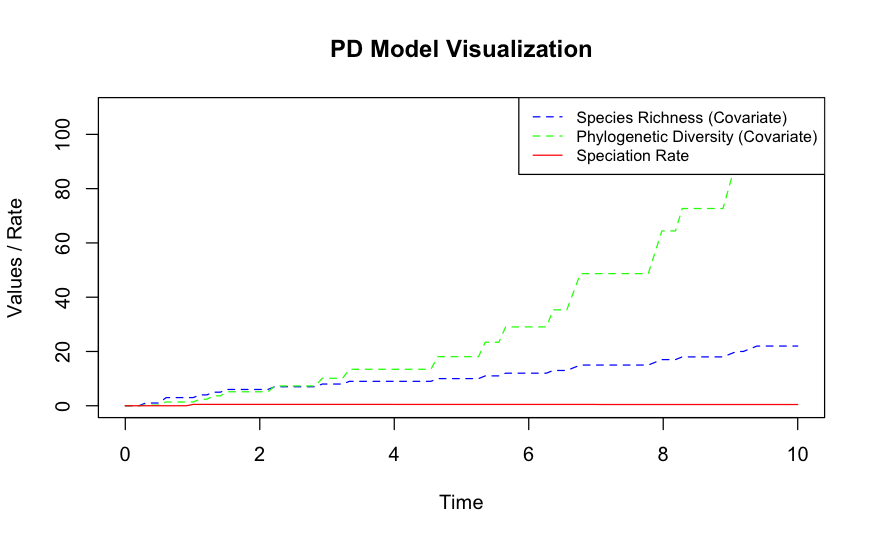

```r
lines(time_points, speciation_rate_values, col = 'red', lty = 1) # Solid line for speciation rate

# Add a legend
legend('topright', legend = c('Species Richness (Covariate)', 'Phylogenetic Diversity (Covariate)', 'Speciation Rate'),
       col = c('blue', 'green', 'red'), lty = c(2, 2, 1), cex = 0.8)
```

```r
NA
NA
NA
NA
```

The Phylogenetic Diversification (PD) model describes the speciation rate over time within a phylogenetic tree. The model takes into account both speciation and extinction events, and it can be mathematically described by the following equations:

The speciation rate $\lambda_s(t)$ at time $t$ is given by:

$$\lambda_s(t | \lambda_0, \beta_N, \beta_P) = \max \left( 0, \lambda_0 +
\beta_N N_t + \beta_P \frac{P_t}{N_t} \right);$$

where:

- $\lambda_0$ is the baseline speciation rate,
- $\beta_N$ is the coefficient for the effect of the number of lineages at time $t$ (denoted $N_t$),
- $\beta_P$ is the coefficient for the effect of the phylogenetic diversity at time $t$ (denoted $P_t$), normalized by the number of lineages $N_t$.

The extinction rate $\mu_s(t)$ is assumed to be constant over time, denoted by $\mu_0$:

$$\mu_s(t | \mu_0) = \mu_0$$

The PD model ensures that the speciation rate is non-negative and allows for the simulation of complex evolutionary scenarios.

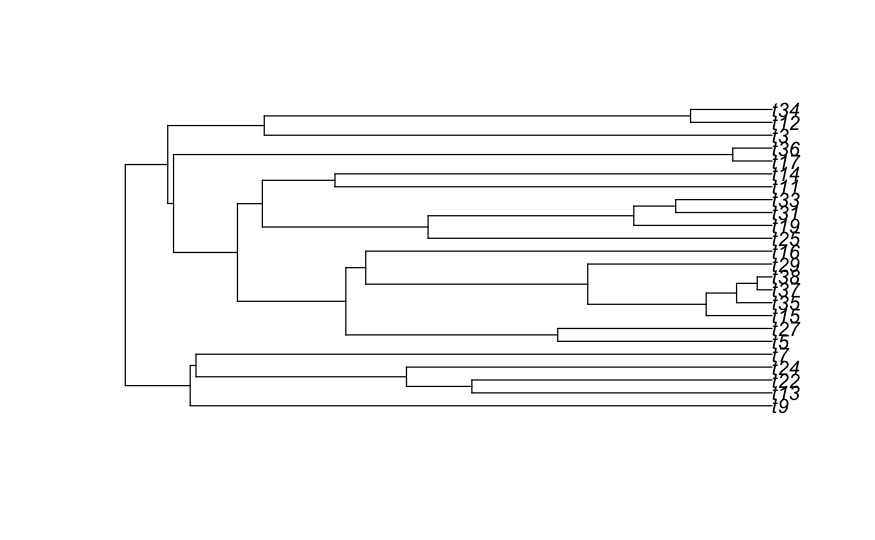

```r
plot(tree)
```

```r
larger_tree = tree
# Define time points for visualization, ensuring they don't exceed the tree age
max_time <- max(branching.times(larger_tree))
time_points <- seq(0, max_time, length.out = 100)

# Compute species richness and phylogenetic diversity at each time point
richness_values <- sapply(time_points, function(t) sum(branching.times(larger_tree) < t))
diversity_values <- sapply(time_points, function(t) sum(branching.times(larger_tree)[branching.times(larger_tree) < t]))

# Compute the speciation rate at each time point
params <- c(lambda_0 = 0.5, beta_N = 1.2, beta_P = -0.8)
speciation_rate_values <- sapply(time_points, function(t) {
  Nt <- richness_values[t]
  Pt <- diversity_values[t]
  lambda_t <- max(0, params['lambda_0'] + params['beta_N'] * Nt + params['beta_P'] * Pt / max(Nt, 1))
  return(lambda_t)
})

# Plot species richness, phylogenetic diversity, and speciation rate
plot(time_points, richness_values, type = 'l', col = 'blue', lty = 2,
     ylim = range(c(richness_values, diversity_values, speciation_rate_values)),
     main = 'PD Model Visualization on Larger Tree', xlab = 'Time', ylab = 'Values / Rate')
lines(time_points, diversity_values, col = 'green', lty = 2)
```

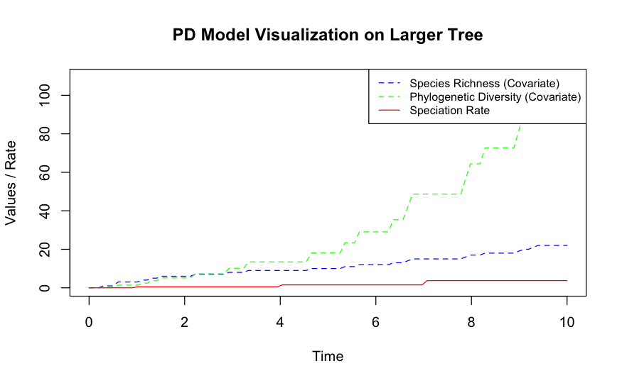

```r
lines(time_points, speciation_rate_values, col = 'red', lty = 1)

# Add a legend
legend('topright', legend = c('Species Richness (Covariate)', 'Phylogenetic Diversity (Covariate)', 'Speciation Rate'),
       col = c('blue', 'green', 'red'), lty = c(2, 2, 1), cex = 0.8)
```

### Augmentation of Phylogenetic Trees

Phylogenies that are derived from molecular data (e.g. DNA sequences) are, however, not full trees, as they do not contain the extinct species. The likelihood for an observed tree can be written in terms of the likelihood of compatible full trees. In principle, this is simply the integration over all possible full trees that are compatible with the observed tree $x_{obs}$:

$$\begin{equation}
f(x_{obs}|\theta) = \displaystyle\int_{x \in
\mathcal{X}(x_{obs})} \exp(\ell _{x} (\theta|x_{obs})) dx
\label{logy}
\end{equation}$$

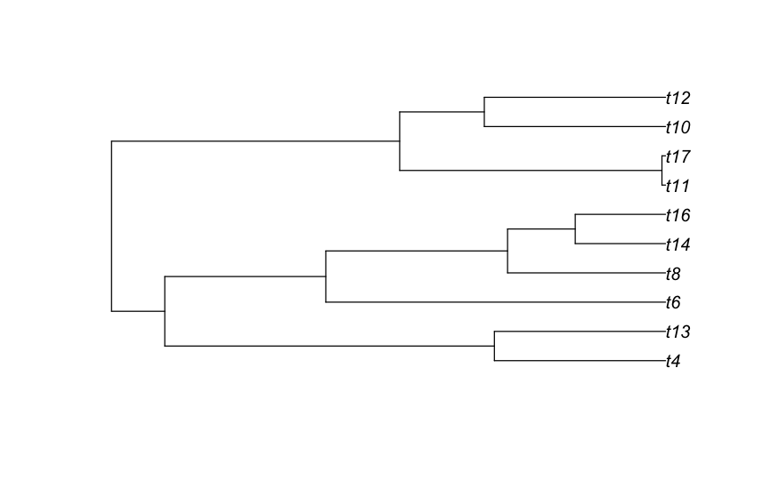

```r
pars =c(0.21779984 ,1.16601633, -0.08090578 , 0.01261866)
tree = sim_tree_pd_cpp(pars = pars,max_t = 5,max_lin = 1e+7,max_tries = 1)
phylo = tree$tes
plot(phylo)
```

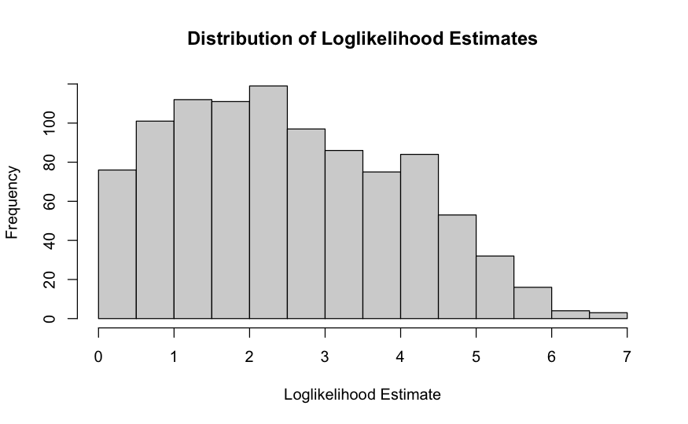

```r
brts <- ape::branching.times(phylo)

# Define parameter bounds
lower_bound = c(0,0.5,-0.1,0)
upper_bound = c(1,3,0,0.1)

num_points <- 1000

pars <- matrix(nrow = num_points, ncol = length(lower_bound))
for (i in seq_along(lower_bound)) {
  pars[, i] <- runif(num_points, min = lower_bound[i], max = upper_bound[i])
}

dmval <- mcGrid(pars,
                brts = brts,
                sample_size = 1,
                maxN = 1,
                soc = 2,
                max_missing = 1e+4,
                max_lambda = 1e+4,
                lower_bound = lower_bound,
                upper_bound = upper_bound,
                xtol_rel = 0.01,
                num_threads = 4)
# Extract relevant columns
loglikelihood_est <- dmval[, 1]
sampled_x_loglikelihood <- dmval[, 5]
sampling_probability <- dmval[, 6]

# Remove rows with NA in loglikelihood_est
valid_indices <- !is.na(loglikelihood_est)
loglikelihood_est <- loglikelihood_est[valid_indices]
sampled_x_loglikelihood <- sampled_x_loglikelihood[valid_indices]
sampling_probability <- sampling_probability[valid_indices]

# Plotting the distribution of loglikelihood estimates
hist(sampling_probability/loglikelihood_est, main="Distribution of Loglikelihood Estimates", xlab="Loglikelihood Estimate")
```

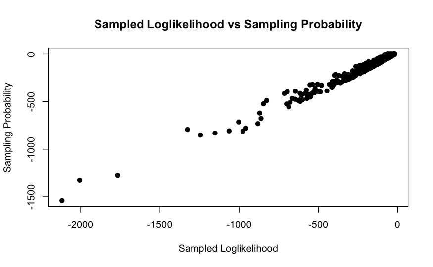

```r
# Scatter plot of sampled_x_loglikelihood vs sampling_probability
plot(sampled_x_loglikelihood, sampling_probability, main="Sampled Loglikelihood vs Sampling Probability",
     xlab="Sampled Loglikelihood", ylab="Sampling Probability", pch=19)
```

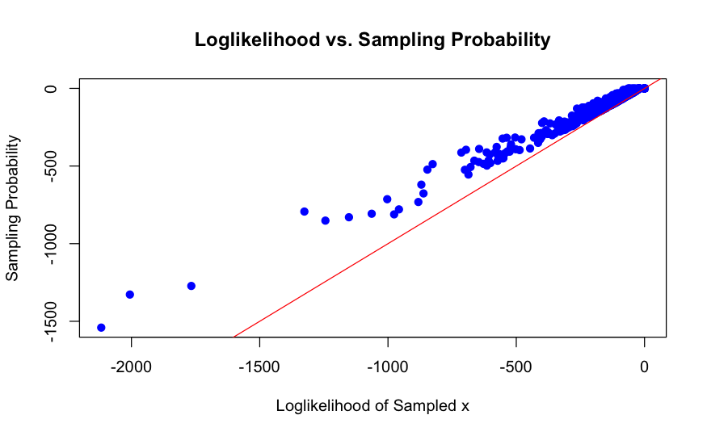

```r
# Adding a line to visualize the ideal sampling distribution might require additional theoretical information
# For simplicity, this example focuses on the distributions and relationships in the sampled data


# Assuming dmval is your matrix
plot(dmval[,5], dmval[,6], main = "Loglikelihood vs. Sampling Probability",
     xlab = "Loglikelihood of Sampled x", ylab = "Sampling Probability",
     pch = 19, col = "blue")

# Adding a 1:1 line for perfect agreement
abline(a = 0, b = 1, col = "red")
```

```r
# Calculate correlation
correlation <- cor(dmval[,5], dmval[,6], use = "complete.obs")
cat("Correlation between Loglikelihood of Sampled x and Sampling Probability: ", correlation, "\n")
```

```
Correlation between Loglikelihood of Sampled x and Sampling Probability:  0.9880119
```

### Loading and visualizing agumented data

```r
# load simulation data
path_data = "~/Library/CloudStorage/Dropbox/Pancho/78 - GAM paper/01 - Simulation data/Parulidae_20240205_233041.RData"
process_and_plot(path_data)
```

[output not shown]